# re_lm02

Simon Rüegg

2025-05-04

# Report exercise

```r
#Loading the libraries
library(dplyr)
library(ggplot2)
library(readr)
library(tidyr)
library(caret)
library(recipes)
```

## 1: Characteristics of the two diffrent data sites Davos and Laegern

```r
# Loading the data
flux_davos <- read.csv("../data/FLX_CH-Dav_FLUXNET2015_FULLSET_DD_1997-2014_1-3.csv") #Data from Davos
flux_laegern <- read.csv("../data/FLX_CH-Lae_FLUXNET2015_FULLSET_DD_2004-2014_1-4.csv") #Data from Laegern
```

Information of for the diffrent sites can be found in a file, which tells the characteristics for each site.

```r
# Loading the file with the characteristics for the diffrent sites
siteinfo_flux <- load("../data/siteinfo_fluxnet2015(2).rda") #siteinfo_fluxnet2015 get loaded in the environment
siteinfo_fluxnet2015 |>
  filter(sitename %in% c("CH-Dav", "CH-Lae")) #just getting the characteristic for the site of Davos and Laegern.
```

```
## # A tibble: 2 × 12
##   sitename   lon   lat   elv year_start year_end classid c4      whc
##   <chr>    <dbl> <dbl> <dbl> <chr>      <chr>    <chr>   <lgl> <dbl>
## 1 CH-Dav    9.86  46.8  1639 1997       2014     ENF     FALSE  172.
## 2 CH-Lae    8.36  47.5   689 2004       2014     MF      FALSE  292.
## # ℹ 3 more variables: koeppen_code <chr>, igbp_land_use <chr>,
## #   plant_functional_type <chr>
```

From this file above we get the different characteristics from Dabos and Leagern. Both sides have an similiar latitude. The site of Laegern is a bit more north. There is a big diffrens with the elavation. The site of Davos is nearly 1000 Meters higher the the site of Laegern. Davos has an elavation of 1639 meters above sealevel, Lagern on of 689 Meter above sealevel. There is also a diffrence in the igbp_land_use und the plant_functional_type. While Davos is mostly an evergreen needleleaf forest, Laegern is a mixed forest with mostly decidous broadleaf trees.

## 2: Training the KNN-models

Wrangling Data

```r
# Splitting Data for Davos
flux_davos <- flux_davos |>

  # select only the variables we are interested in
  dplyr::select(TIMESTAMP,
                GPP_NT_VUT_REF,    # the target
                ends_with("_QC"),  # quality control info
                ends_with("_F"),   # includes all all meteorological covariates
                -contains("JSB")   # weird useless variable
                ) |>

  # convert to a nice date object
  dplyr::mutate(TIMESTAMP = lubridate::ymd(TIMESTAMP)) |>

  # set all -9999 to NA
  dplyr::mutate(across(where(is.numeric), ~na_if(., -9999))) |>


  # retain only data based on >=80% good-quality measurements
  # overwrite bad data with NA (not dropping rows)
  dplyr::mutate(GPP_NT_VUT_REF = ifelse(NEE_VUT_REF_QC < 0.8, NA, GPP_NT_VUT_REF),
                TA_F           = ifelse(TA_F_QC        < 0.8, NA, TA_F),
                SW_IN_F        = ifelse(SW_IN_F_QC     < 0.8, NA, SW_IN_F),
                LW_IN_F        = ifelse(LW_IN_F_QC     < 0.8, NA, LW_IN_F),
                VPD_F          = ifelse(VPD_F_QC       < 0.8, NA, VPD_F),
                PA_F           = ifelse(PA_F_QC        < 0.8, NA, PA_F),
                P_F            = ifelse(P_F_QC         < 0.8, NA, P_F),
                WS_F           = ifelse(WS_F_QC        < 0.8, NA, WS_F)) |>

  # drop QC variables (no longer needed)
  dplyr::select(-ends_with("_QC"))



# Splitting Data for Laegern
flux_laegern <- flux_laegern|>

  # select only the variables we are interested in
  dplyr::select(TIMESTAMP,
                GPP_NT_VUT_REF,    # the target
                ends_with("_QC"),  # quality control info
                ends_with("_F"),   # includes all all meteorological covariates
                -contains("JSB")   # weird useless variable
                ) |>

  # convert to a nice date object
  dplyr::mutate(TIMESTAMP = lubridate::ymd(TIMESTAMP)) |>

  # set all -9999 to NA
  dplyr::mutate(across(where(is.numeric), ~na_if(., -9999))) |>


  # retain only data based on >=80% good-quality measurements
  # overwrite bad data with NA (not dropping rows)
  dplyr::mutate(GPP_NT_VUT_REF = ifelse(NEE_VUT_REF_QC < 0.8, NA, GPP_NT_VUT_REF),
                TA_F           = ifelse(TA_F_QC        < 0.8, NA, TA_F),
                SW_IN_F        = ifelse(SW_IN_F_QC     < 0.8, NA, SW_IN_F),
                LW_IN_F        = ifelse(LW_IN_F_QC     < 0.8, NA, LW_IN_F),
                VPD_F          = ifelse(VPD_F_QC       < 0.8, NA, VPD_F),
                PA_F           = ifelse(PA_F_QC        < 0.8, NA, PA_F),
                P_F            = ifelse(P_F_QC         < 0.8, NA, P_F),
                WS_F           = ifelse(WS_F_QC        < 0.8, NA, WS_F)) |>

  # drop QC variables (no longer needed)
  dplyr::select(-ends_with("_QC"))
```

Checking data of completeness

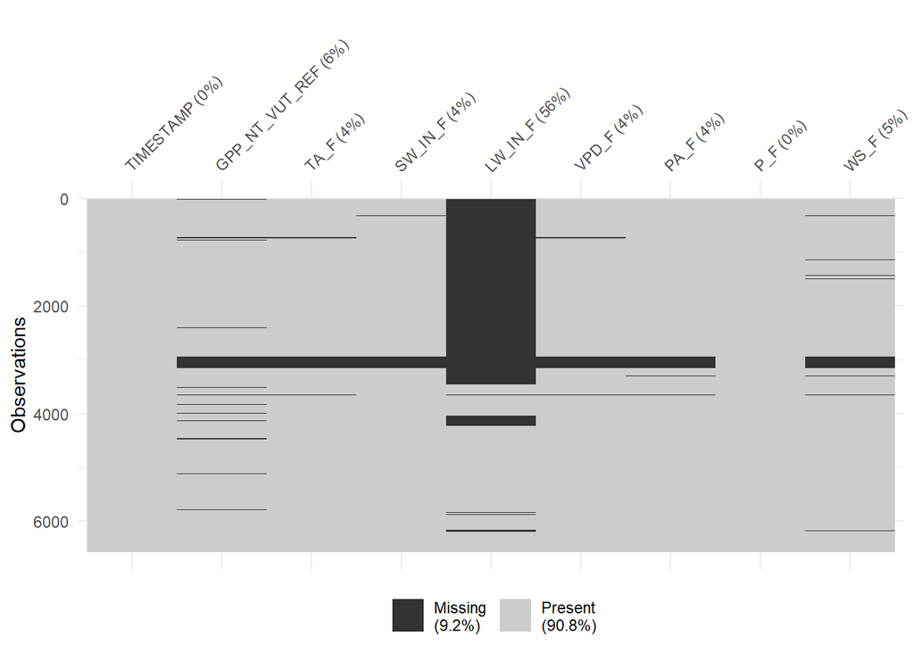

```r
# Checking for Davos
visdat::vis_miss(
  flux_davos,
  cluster = FALSE,
  warn_large_data = FALSE
  ) # alot of missing values in of the variable LW_IN_F
```

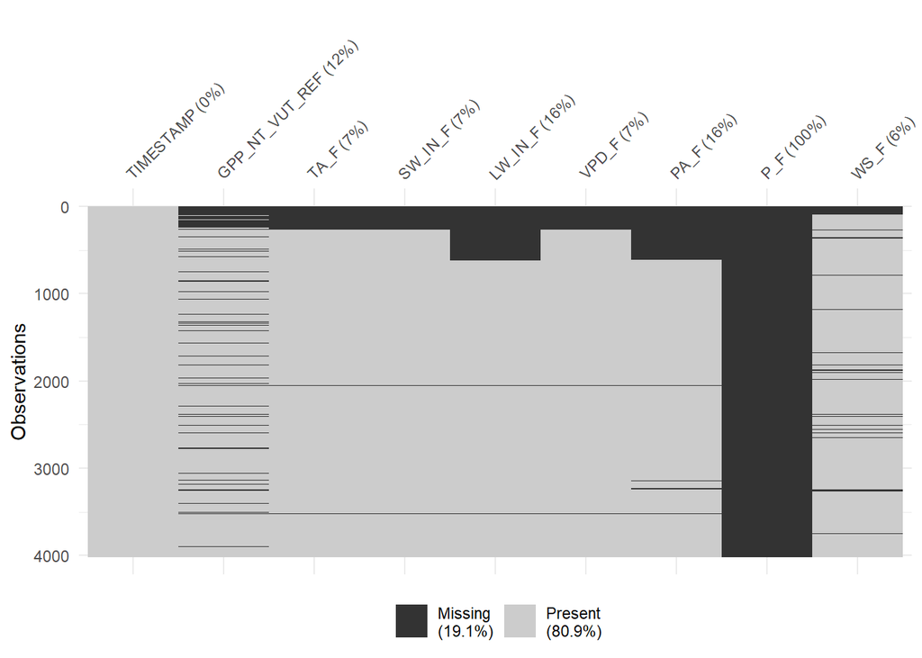

```r
# Checking for Laegern
visdat::vis_miss(
  flux_laegern,
  cluster = FALSE,
  warn_large_data = FALSE
  ) # For laegern there are ni values for P_F. Not using these variabe for the modelling and comparing
```

Wrangling Data

```r
# Eliminating the variables LW_IN_F and P_F for Davos
flux_davos <- flux_davos |>
  dplyr::select(-LW_IN_F) |>
  dplyr::select(-P_F)

# Eliminating the variables LW_IN_F and P_F for Laegern
flux_laegern <- flux_laegern |>
  dplyr::select(-LW_IN_F) |>
  dplyr::select(-P_F)
```

Combine Davos and Lagern

```r
flux_davos_laegern <- bind_rows(flux_davos, flux_laegern)
```

## 2: Splitting data and Training KNN models

Splitting the Data into training set and test set

```r
# Data splitting of Davos
set.seed(123)  # for reproducibility
split_davos <- rsample::initial_split(flux_davos, prop = 0.8, strata = "VPD_F")
fluxes_davos_train <- rsample::training(split_davos)
fluxes_davos_test <- rsample::testing(split_davos)

# Data splitting of Laegern
set.seed(123)  # for reproducibility
split_laegern <- rsample::initial_split(flux_laegern, prop = 0.8, strata = "VPD_F")
fluxes_laegern_train <- rsample::training(split_laegern)
fluxes_laegern_test <- rsample::testing(split_laegern)

# Data splitting of the combinaton Davos & Laegern
set.seed(123)  # for reproducibility
split_davos_laegern <- rsample::initial_split(flux_davos_laegern, prop = 0.8, strata = "VPD_F")
fluxes_davos_laegern_train <- rsample::training(split_davos_laegern)
fluxes_davos_laegern_test <- rsample::testing(split_davos_laegern)
```

Training KNN model for site Davos

```r
pp_davos <- recipes::recipe(GPP_NT_VUT_REF ~ SW_IN_F + VPD_F + TA_F,
                      data = fluxes_davos_train) |>
  recipes::step_center(recipes::all_numeric(), -recipes::all_outcomes()) |>
  recipes::step_scale(recipes::all_numeric(), -recipes::all_outcomes())

set.seed(1982)
mod_cv_davos <- caret::train(pp_davos,
                       data = fluxes_davos_train |> drop_na(),
                       method = "knn",
                       trControl = caret::trainControl(method = "cv", number = 10),
                       tuneGrid = data.frame(k = c(2, 5, 10, 15, 20, 25, 30, 35, 40, 60, 100)),
                       metric = "MAE")
print(mod_cv_davos)
```

```
## k-Nearest Neighbors
##
## 4835 samples
##    6 predictor
##
## Recipe steps: center, scale
## Resampling: Cross-Validated (10 fold)
## Summary of sample sizes: 4351, 4352, 4351, 4351, 4351, 4352, ...
## Resampling results across tuning parameters:
##
##   k    RMSE      Rsquared   MAE
##     2  1.736226  0.6223790  1.311226
##     5  1.538572  0.6905558  1.164405
##    10  1.489822  0.7081185  1.124404
##    15  1.470884  0.7151942  1.109923
##    20  1.457882  0.7201648  1.101819
##    25  1.455337  0.7210957  1.098681
##    30  1.454638  0.7213233  1.098989
##    35  1.452782  0.7220854  1.098925
##    40  1.454683  0.7214336  1.101120
##    60  1.456935  0.7208256  1.107093
##   100  1.461789  0.7192690  1.112441
##
## MAE was used to select the optimal model using the smallest value.
## The final value used for the model was k = 25.
```

Training KNN model for site of Laegern

```r
pp_laegern <- recipes::recipe(GPP_NT_VUT_REF ~ SW_IN_F + VPD_F + TA_F,
                      data = fluxes_laegern_train) |>
  recipes::step_center(recipes::all_numeric(), -recipes::all_outcomes()) |>
  recipes::step_scale(recipes::all_numeric(), -recipes::all_outcomes())

set.seed(1982)
mod_cv_laegern <- caret::train(pp_laegern,
                       data = fluxes_laegern_train |> drop_na(),
                       method = "knn",
                       trControl = caret::trainControl(method = "cv", number = 10),
                       tuneGrid = data.frame(k = c(2, 5, 10, 15, 20, 25, 30, 35, 40, 60, 100)),
                       metric = "MAE")
print(mod_cv_laegern)
```

```
## k-Nearest Neighbors
##
## 2440 samples
##    6 predictor
##
## Recipe steps: center, scale
## Resampling: Cross-Validated (10 fold)
## Summary of sample sizes: 2196, 2196, 2196, 2196, 2196, 2196, ...
## Resampling results across tuning parameters:
##
##   k    RMSE      Rsquared   MAE
##     2  2.917323  0.5615422  2.217293
##     5  2.664351  0.6155595  2.019886
##    10  2.540658  0.6470808  1.927968
##    15  2.510923  0.6551288  1.898179
##    20  2.492589  0.6602226  1.882974
##    25  2.499504  0.6584409  1.886039
##    30  2.506437  0.6566054  1.890574
##    35  2.514194  0.6546082  1.893435
##    40  2.520254  0.6531255  1.895508
##    60  2.538293  0.6485425  1.910750
##   100  2.586642  0.6354722  1.956757
##
## MAE was used to select the optimal model using the smallest value.
## The final value used for the model was k = 20.
```

Training KNN model for the combination of Davos and Laegern

```r
pp_davos_laegern <- recipes::recipe(GPP_NT_VUT_REF ~ SW_IN_F + VPD_F + TA_F,
                      data = fluxes_davos_laegern_train) |>
  recipes::step_center(recipes::all_numeric(), -recipes::all_outcomes()) |>
  recipes::step_scale(recipes::all_numeric(), -recipes::all_outcomes())

set.seed(1982)
mod_cv_davos_laegern <- caret::train(pp_davos_laegern,
                       data = fluxes_davos_laegern_train |> drop_na(),
                       method = "knn",
                       trControl = caret::trainControl(method = "cv", number = 10),
                       tuneGrid = data.frame(k = c(2, 5, 10, 15, 20, 25, 30, 35, 40, 60, 100)),
                       metric = "MAE")
print(mod_cv_davos_laegern)
```

```
## k-Nearest Neighbors
##
## 7294 samples
##    6 predictor
##
## Recipe steps: center, scale
## Resampling: Cross-Validated (10 fold)
## Summary of sample sizes: 6565, 6564, 6564, 6564, 6565, 6564, ...
## Resampling results across tuning parameters:
##
##   k    RMSE      Rsquared   MAE
##     2  2.381029  0.5519947  1.757730
##     5  2.151511  0.6174838  1.583365
##    10  2.074368  0.6410819  1.524223
##    15  2.050015  0.6489041  1.509151
##    20  2.041955  0.6513944  1.505970
##    25  2.033894  0.6541971  1.500417
##    30  2.030074  0.6555263  1.497543
##    35  2.026839  0.6566564  1.495349
##    40  2.023236  0.6580092  1.493102
##    60  2.025573  0.6575584  1.497482
##   100  2.036980  0.6541869  1.511071
##
## MAE was used to select the optimal model using the smallest value.
## The final value used for the model was k = 40.
```

Model trained with data from Davos

```r
# fit KNN model for Davos
k_davos <- mod_cv_davos$finalModel$k #optimal k for davos

mod_knn_davos <- caret::train(
  pp_davos,
  data = fluxes_davos_train |> drop_na(),
  method = "knn",
  trControl = caret::trainControl(method = "none"),
  tuneGrid = data.frame(k = k_davos),
  metric = "RMSE"
)

source("../R/eval_model_rmse_rsq.R")

# Evaluate model for Davos versus Davos, Laegern and the combination of Davos and Laegern
davos_davos <- eval_model_rmse_rsq(mod = mod_knn_davos, df_train = fluxes_davos_train, df_test = fluxes_davos_test) #Davos vs. Davos
davos_laegern <- eval_model_rmse_rsq(mod = mod_knn_davos, df_train = fluxes_davos_train, df_test = fluxes_laegern_test) #Davos vs. Laegern
davos_davoslaegern <- eval_model_rmse_rsq(mod = mod_knn_davos, df_train = fluxes_davos_laegern_train, df_test = fluxes_davos_laegern_test) #Davos vs. Davos-Laegern
```

Model trained with data from Laegern

```r
# fit KNN model for Davos
k_laegern <- mod_cv_laegern$finalModel$k #optimal k for davos

mod_knn_laegern <- caret::train(
  pp_laegern,
  data = fluxes_laegern_train |> drop_na(),
  method = "knn",
  trControl = caret::trainControl(method = "none"),
  tuneGrid = data.frame(k = k_laegern),
  metric = "RMSE"
)

source("../R/eval_model_rmse_rsq.R")

# Evaluate model for Davos versus Davos, Laegern and the combination of Davos and Laegern
laegern_laegern <- eval_model_rmse_rsq(mod = mod_knn_laegern, df_train = fluxes_laegern_train, df_test = fluxes_laegern_test) #Laegern vs. Laegern
laegern_davos <- eval_model_rmse_rsq(mod = mod_knn_laegern, df_train = fluxes_laegern_train, df_test = fluxes_davos_test) #Laegern vs. Davos
laegern_davoslaegern <- eval_model_rmse_rsq(mod = mod_knn_laegern, df_train = fluxes_laegern_train, df_test = fluxes_davos_laegern_test) # Laegern vs. Davos-Laegern
```

Model trained with data from the combination of Davos-Laegern

```r
# fit KNN model for Davos
k_davos_laegern <- mod_cv_davos_laegern$finalModel$k #optimal k for davos

mod_knn_davos_laegern <- caret::train(
  pp_davos_laegern,
  data = fluxes_davos_laegern_train |> drop_na(),
  method = "knn",
  trControl = caret::trainControl(method = "none"),
  tuneGrid = data.frame(k = k_laegern),
  metric = "RMSE"
)

source("../R/eval_model_rmse_rsq.R")

# Evaluate model for Davos versus Davos, Laegern and the combination of Davos and Laegern
davoslaegern_davoslaegern <- eval_model_rmse_rsq(mod = mod_knn_davos_laegern, df_train = fluxes_davos_laegern_train, df_test = fluxes_davos_laegern_test) #Laegern vs. Laegern
davoslaegern_davos <- eval_model_rmse_rsq(mod = mod_knn_davos_laegern, df_train = fluxes_davos_laegern_train, df_test = fluxes_davos_test) #Laegern vs. Davos
davoslaegern_laegern <- eval_model_rmse_rsq(mod = mod_knn_davos_laegern, df_train = fluxes_davos_laegern_train, df_test = fluxes_laegern_test) # Laegern vs. Davos-Laegern
```

## 3: Creating tables

Table for Davos

```r
table_davos <- data.frame(
  row.names = c("Evaluation against Laegern test set", "Evaluation agains Davos test set", "Evaluation against Laegern & Davos test set"),
  "RSQ" = c(davos_laegern[2], davos_davos[2], davos_davoslaegern[2]),
  "RMSE" = c(davos_laegern[1], davos_davos[1], davos_davoslaegern[1])
)

knitr::kable(table_davos, format = "html", caption = "Model trained on data from Davos") |>
  kableExtra::kable_styling(
    bootstrap_options = c("striped", "hover", "condensed", "responsive"),
    full_width = FALSE,
    position = "center"
  )
```

Model trained on data from Davos

|  | RSQ | RMSE |
| --- | --- | --- |
| Evaluation against Laegern test set | 0.5578318 | 3.306739 |
| Evaluation agains Davos test set | 0.7256779 | 1.454097 |
| Evaluation against Laegern & Davos test set | 0.5894612 | 2.290695 |

Table for Laegern

```r
table_laegern <- data.frame(
  row.names = c("Evaluation against Laegern test set", "Evaluation agains Davos test set", "Evaluation against Laegern & Davos test set"),
  "RSQ" = c(laegern_laegern[2], laegern_davos[2], laegern_davoslaegern[2]),
  "RMSE" = c(laegern_laegern[1], laegern_davos[1], laegern_davoslaegern[1])
)

knitr::kable(table_laegern, format = "html", caption = "Model trained on data from Laegern") |>
  kableExtra::kable_styling(
    bootstrap_options = c("striped", "hover", "condensed", "responsive"),
    full_width = FALSE,
    position = "center"
  )
```

Model trained on data from Laegern

|  | RSQ | RMSE |
| --- | --- | --- |
| Evaluation against Laegern test set | 0.6841219 | 2.426384 |
| Evaluation agains Davos test set | 0.5343254 | 2.371947 |
| Evaluation against Laegern & Davos test set | 0.6034062 | 2.363833 |

Table for Davos & Laegern

```r
table_davoslaegern <- data.frame(
  row.names = c("Evaluation against Laegern test set", "Evaluation agains Davos test set", "Evaluation against Laegern & Davos test set"),
  "RSQ" = c(davoslaegern_laegern[2], davoslaegern_davos[2], davoslaegern_davoslaegern[2]),
  "RMSE" = c(davoslaegern_laegern[1], davoslaegern_davos[1], davoslaegern_davoslaegern[1])
)

knitr::kable(table_davoslaegern, format = "html", caption = "Model trained on data from Laegern & Davos") |>
  kableExtra::kable_styling(
    bootstrap_options = c("striped", "hover", "condensed", "responsive"),
    full_width = FALSE,
    position = "center"
  )
```

Model trained on data from Laegern & Davos

|  | RSQ | RMSE |
| --- | --- | --- |
| Evaluation against Laegern test set | 0.6743900 | 2.562828 |
| Evaluation agains Davos test set | 0.7103680 | 1.538440 |
| Evaluation against Laegern & Davos test set | 0.6594505 | 2.037218 |

## 4: Comparing of the different results

As we can see in the tables R^2 is best if the test sets of the models for Davos and Leagern are tested against there training set of there one site. This can be expected, because the environment is the same because the data are from the same side. Interesting to see is that for the training set with data from Davos and Laegern the R^2-value for the test set Davos is nearly as good as for the trained model just from Davos. The RMSE-value is best for the model of Davos tested against the test set of Davos. Also the model from the combination of Laegern and Davos is good when tested aginst the test set of Davos. All the other RMSE values are not that good neither they compered against there one test set or a test set from another site or a combination of two sites. The model from Laegern and Laegern-Davos do not work as bad as the model from Davos compared the the test set of Laegern. This could be explained that the model for Laegern and Laegern-Davos is testet in a mixed forest with needle and leaf trees, and the model in Davos just with needle trees. So in the model form Davos there are no Data how leaf influnce the GPP. The training and testing on both sites is not a “true out-of-sample” because training data from the combination could be in the testing set of Davos or Laegern. To make a “true out-of sample” combination of the two data sets must be done after the split in training and testing data with the data from Davos and Laegern. If the model of Davos-Laegern is tested against a site in Spain I would expect that it is not that good. This because the weather and temperature is very different than in Switzerland. Also the might be growing other trees or bushes. That is why I would say its not that good of a model for a site in Spain.